# Mini-Project 02

# Data Visualization Project 02

## Executive Summary

The purpose of this project was to analyze service complaints in NYC and gain insights into the types of complaints and their geographical distribution. The data set used in this analysis contained information about complaint types, locations, and counts.

### Motivation

My main motivation came from the Ted Talk I watched this week. Ben Wellington was talking about the Open Data Plattform for NYC and showed what he created with the information provided. Therefore, I wanted to try to work on something similar. I’ve never heard of the 311 service before but found the concept interesting. I wanted to know for what issues and complaints people use 311.

### Description of the data

311 allows you easy access to non-emergency police services. It gives you the opportunity to talk to police personel in your district. NYC OpenData makes the data generated by various New York City Agencies public. It is automatically updated daily and contains of 46 columns. For my analysis, I only use five columns. Those are Complaint Type, City, Longitude, Latitude, and the Date of Complaint.

### Data Visualizations

To visually represent the findings, several data visualizations were created:

Spatial Map: A spatial map was created to depict the geographical distribution of service complaints. Different complaint types were represented by color-coded markers, allowing for easy identification of complaint hotspots.

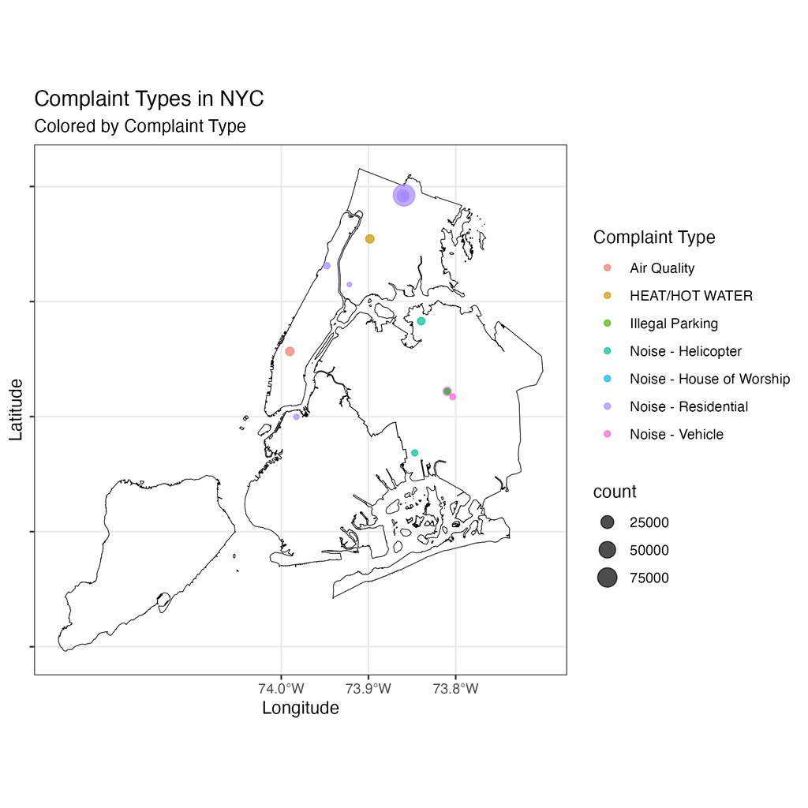

Lollipop chart: A lollipop graph was used to illustrate the coefficients of a multionomial regression undertaken to understand the relationship between latitude and different complaint types.

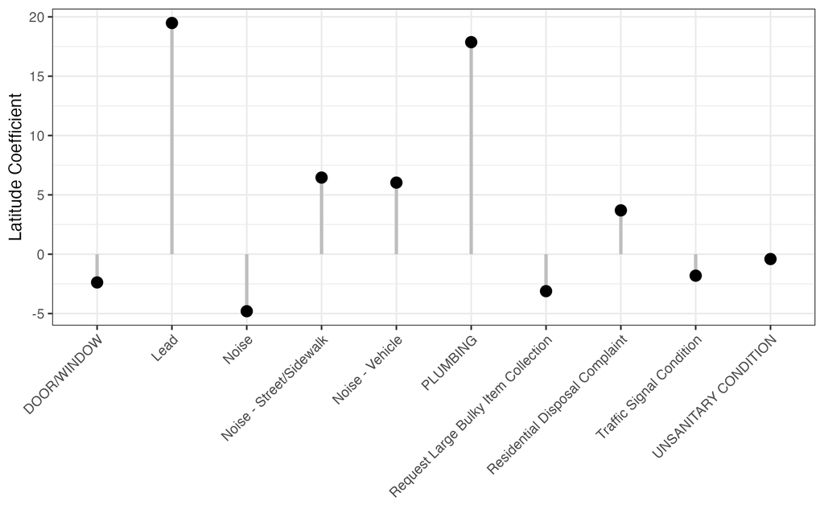